# ManyBabies Norming Analysis

# Data loading and cleaning

Read in files and consolidate to the same directory.

```r
files <- dir("../production-results/")
d.raw <- tibble()

for (f in files) {
  jf <- paste("../production-results/",f,sep="")
  jd <- fromJSON(paste(readLines(jf), collapse=""))
  id <- data.frame(workerid = jd$WorkerId,
                   rating = as.numeric(jd$answers$data$rating),
                   file = jd$answers$data$filename,
                   condition = jd$answers$data$condition,
                   age = jd$answers$data$age,
                   language = jd$answers$data$homelang,
                   race = jd$answers$data$race[1],
                   education = jd$answers$data$education,
                   children = jd$answers$data$children)
  d.raw <- bind_rows(d.raw, id)
}
```

Exclude non-compliant participants and non-English speakers.

```r
compliant <- d.raw %>%
  filter(grepl("choose", file)) %>%
  mutate(file = as.numeric(str_replace(str_replace(file, "\\.\\./choose_", ""),
                            "\\.wav", ""))) %>%
  mutate(compliant = rating == file) %>%
  group_by(workerid) %>%
  summarise(compliant = mean(compliant) == 1)

english <- d.raw %>%
  group_by(workerid, language) %>%
  distinct() %>%
  filter(str_detect(pattern = "[eE]nglish", language))

d <- d.raw %>%
  filter(workerid %in% compliant$workerid,
         workerid %in% english$workerid,
         !str_detect(file, pattern = "choose_"))
```

Merge in filename data.

```r
file_info <- read_csv("../wavs/file_key.csv")

d <- left_join(d, file_info)
```

Distribution across conditions.

```r
d %>%
  group_by(condition, workerid) %>%
  distinct %>%
  group_by(condition) %>%
  summarise(n =n()) %>%
  kable
```

| condition | n |
| --- | --- |
| accent | 14 |
| affect | 8 |
| idsness | 10 |
| naturalness | 18 |
| noise | 13 |

# Main analysis

Major summary histogram.

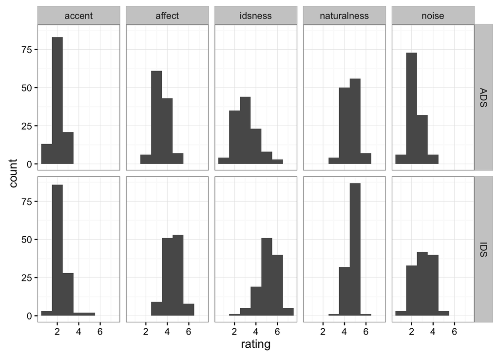

```r
d %>%
  mutate(object = !is.na(object)) %>%
  group_by(file, condition, register, object) %>%
  summarise(rating = mean(rating)) %>%
ggplot(aes(x = rating)) +
  geom_histogram(binwidth=1) +
  facet_grid(register~condition) +
  theme_bw()
```

Check correlations between raters.

```r
d %>%
  split(.$condition) %>%
  map_df(function(x) {
    cors <- x %>%
      select(workerid, rating, file) %>%
      spread(workerid, rating) %>%
      select(-file) %>%
      cor
    cors[cors == 1] <- NA
    tibble(condition = x$condition[1],
           cor = mean(cors, na.rm=TRUE),
           min = min(cors, na.rm=TRUE),
           max = max(cors, na.rm=TRUE))
  }) %>%
  kable(digits = 2)
```

| condition | cor | min | max |
| --- | --- | --- | --- |
| accent | 0.19 | -0.12 | 0.54 |
| affect | 0.32 | 0.01 | 0.65 |
| idsness | 0.48 | 0.03 | 0.71 |
| naturalness | 0.05 | -0.67 | 0.70 |
| noise | 0.42 | 0.12 | 0.75 |

# Filtering analysis

As described by Melanie in an email 8/2/16.

*Step 1: Select items that meet the following criteria only*

- Accent: 1-2 only.
- Naturalness: 4-7 only
- IDS/ADS: 1-3 or 5-7 only (as appropriate)
- Noise: 1-3 (or should we be more strict? Given these were all selected to be pretty noise-free to begin with, 1-3 might be sufficient)

*Step 2: Match across IDS and ADS on similarity for:*

- Approximate quantity (in duration) of contribution from a given mom
- Quantity of mentions of familiar objects, and unfamiliar objects (or try to match by specific object label?)

*Step 3: Re-check according some criteria of “sameness” (not sure what that should be)*

- Accent, naturalness and noise level are similar between IDS and ADS and we haven’t created a systematic bias in Step 2.

```r
filtered <- d %>%
  group_by(condition, register, object, baby_id, recording_id, file) %>%
  summarize(rating = mean(rating)) %>%
  spread(condition, rating) %>%
  filter(accent < 3, naturalness > 4, noise < 4,
         (register == "IDS" & idsness > 4) | (register == "ADS" & idsness < 4))

filtered
```

```
## Source: local data frame [163 x 10]
## Groups: register, object, baby_id, recording_id [163]
##
##    register object     baby_id    recording_id
##       <chr>  <chr>       <chr>           <chr>
## 1       ADS   ball   1266_1081    994965918577
## 2       ADS   ball     2077_12 582301715046901
## 3       ADS   ball    3214_461   6955604692438
## 4       ADS   ball    3214_464   7267987032388
## 5       ADS   ball 3314 at 104             602
## 6       ADS   ball 3314 at 115             838
## 7       ADS   ball    4510_341  74610580792717
## 8       ADS  block    1810_458   0540644809489
## 9       ADS  block       4_184     73879609345
## 10      ADS    cup    2077_442   0700898098337
## # ... with 153 more rows, and 6 more variables: file <chr>, accent <dbl>,
## #   affect <dbl>, idsness <dbl>, naturalness <dbl>, noise <dbl>
```

Output.

```r
write_csv(filtered, "../wavs/filtered_and_normed.csv")
```